# Is the log transformation justified?

Fintan Mooney

2026-09-10

```r
rm(list = ls())
project.folder = paste0(print(here::here()), '/')
```

```
## [1] "/Users/fmooney/Documents/hpai_outbreaks_mn"
```

```r
source(paste0(project.folder, 'create_folder_structure.R'))
```

```
## [1] "/Users/fmooney/Documents/hpai_outbreaks_mn"
```

```r
source(paste0(functions.folder, 'script_initiate.R'))
stopifnot(requireNamespace("INLA", quietly = TRUE))
library(INLA); library(Matrix)
INLA::inla.setOption(num.threads = 1)
source(paste0(functions.folder, 'inla_dlnm_helpers.R'))
```

Skewness in a predictor’s marginal distribution is not on its own a reason to transform it. No model assumption concerns the marginal distribution of X. What matters is whether the exposure-response is linear on the link scale, and whether a handful of observations dominate the fit. This file tests those two things directly rather than appealing to skewness, and checks that the direction of every association is unchanged either way.

```r
LOG   <- setDT(readRDS(paste0(objects_folder, "case_crossover_df_sym_g14.RDS")))[state == "Minnesota"]
NOLOG <- setDT(readRDS(paste0(objects_folder, "case_crossover_df_sym_g14_nolog.RDS")))[state == "Minnesota"]
SKEW  <- c("runoff", "precipitation")
LAGS  <- 0:28
```

# 1. Direction of association, logged versus unlogged

The question that matters for interpretation: does anything change sign?

```r
tab_for <- function(d) {
  o <- assemble_cc_dlnm(d, max_lag = 28); f <- fit_cc_inla_dlnm(o)
  list(o = o, f = f, t = lag_window_table(f, o, "cumulative", labels = INLA_LABELS))
}
Ln <- tab_for(LOG); Nn <- tab_for(NOLOG)

num <- function(x) as.numeric(sub("^([0-9.]+).*", "\\1", x))
cmp <- merge(melt(Ln$t, id.vars = "Predictor", variable.name = "window", value.name = "logged"),
             melt(Nn$t, id.vars = "Predictor", variable.name = "window", value.name = "raw"),
             by = c("Predictor", "window"))
cmp[, `:=`(dir_log = fifelse(num(logged) > 1, "+", "-"),
           dir_raw = fifelse(num(raw)    > 1, "+", "-"))]
cmp[, agree := dir_log == dir_raw]
print(cmp[, .(Predictor, window, logged, raw, agree)])
```

```
## Key: <Predictor, window>
##          Predictor      window            logged               raw  agree
##             <char>      <fctr>            <char>            <char> <lgcl>
##  1:   Anseriformes   Lag 0-7 d 1.07 (0.80, 1.43) 0.95 (0.64, 1.39)  FALSE
##  2:   Anseriformes  Lag 8-14 d 1.18 (0.89, 1.57) 1.22 (0.86, 1.70)   TRUE
##  3:   Anseriformes Lag 15-21 d 1.46 (1.10, 1.91) 1.35 (0.98, 1.87)   TRUE
##  4:   Anseriformes Lag 22-28 d 1.66 (1.23, 2.26) 1.02 (0.76, 1.40)   TRUE
##  5:  Precipitation   Lag 0-7 d 0.48 (0.32, 0.73) 0.79 (0.47, 1.31)   TRUE
##  6:  Precipitation  Lag 8-14 d 0.53 (0.39, 0.71) 0.69 (0.49, 0.98)   TRUE
##  7:  Precipitation Lag 15-21 d 0.53 (0.39, 0.71) 0.60 (0.42, 0.85)   TRUE
##  8:  Precipitation Lag 22-28 d 0.53 (0.37, 0.76) 0.52 (0.33, 0.81)   TRUE
##  9:     Snow Cover   Lag 0-7 d 1.09 (0.87, 1.37) 0.82 (0.69, 0.99)  FALSE
## 10:     Snow Cover  Lag 8-14 d 1.02 (0.92, 1.14) 0.91 (0.84, 0.98)  FALSE
## 11:     Snow Cover Lag 15-21 d 0.97 (0.87, 1.08) 0.98 (0.89, 1.08)   TRUE
## 12:     Snow Cover Lag 22-28 d 0.92 (0.76, 1.13) 1.05 (0.88, 1.27)  FALSE
```

[output cut: 17 more lines]

```r
cat(sprintf("\ndirection agrees in %d of %d predictor-window cells\n", sum(cmp$agree), nrow(cmp)))
```

```
##
## direction agrees in 21 of 28 predictor-window cells
```

```r
saveRDS(cmp, paste0(objects_folder, "si_log_direction.RDS"))
```

# 2. Influence: do a few observations carry the estimate?

This is the design-matrix question, and it is the one a transformation can legitimately answer. A case-crossover uses only within-stratum variation, so the relevant quantity is the within-stratum centred exposure. If a small number of cell-days hold most of that variance, they hold most of the coefficient.

```r
within_share <- function(d, v, top = 0.01) {
  cols <- paste0(v, "_Lag", LAGS)
  X <- as.matrix(d[, ..cols])
  # centre each row's stratum out, then ask how concentrated the remaining variance is
  Xc <- X - ave(as.vector(X), rep(d$stratum_id, length(cols)), FUN = mean)
  ss <- Xc^2
  k  <- ceiling(length(ss) * top)
  data.table(variable = unname(INLA_LABELS[v]),
             max_abs_z = round(max(abs(X), na.rm = TRUE), 1),
             skew = round(mean(((X - mean(X)) / sd(X))^3, na.rm = TRUE), 1),
             pct_variance_in_top_1pct = round(100 * sum(sort(ss, decreasing = TRUE)[1:k]) /
                                                sum(ss), 1))
}
lev <- rbind(
  cbind(scale = "logged", rbindlist(lapply(SKEW, function(v) within_share(LOG, v)))),
  cbind(scale = "raw",    rbindlist(lapply(SKEW, function(v) within_share(NOLOG, v)))))
print(dcast(lev, variable ~ scale, value.var = c("max_abs_z", "skew", "pct_variance_in_top_1pct")))
```

```
## Key: <variable>
##          variable max_abs_z_logged max_abs_z_raw skew_logged skew_raw
##            <char>            <num>         <num>       <num>    <num>
## 1:  Precipitation              4.0          12.3         1.3      4.3
## 2: Surface Runoff             14.3          39.4         6.2     17.1
##    pct_variance_in_top_1pct_logged pct_variance_in_top_1pct_raw
##                              <num>                        <num>
## 1:                            10.2                         41.3
## 2:                            59.1                         91.6
```

```r
saveRDS(lev, paste0(objects_folder, "si_log_leverage.RDS"))
```

# 3. Influence: drop the most extreme matched sets and refit

The concentration statistic says the raw scale puts most of its variance in few observations. It does not say that this moves the answer. Individual rows cannot be dropped — removing a day from a matched set changes that set’s own comparison — so strata are ranked by their most extreme exposure and the worst few dropped entirely.

```r
strata_rank <- function(d) {
  cols <- unlist(lapply(SKEW, function(v) paste0(v, "_Lag", LAGS)))
  X <- as.matrix(d[, ..cols])
  data.table(stratum_id = d$stratum_id, m = apply(abs(X), 1, max))[
    , .(m = max(m)), by = stratum_id][order(-m)]
}
run <- function(d, drop_n, label) {
  rk <- strata_rank(d)
  keep <- d[!stratum_id %in% rk$stratum_id[seq_len(drop_n)]]
  o <- assemble_cc_dlnm(keep, max_lag = 28); f <- fit_cc_inla_dlnm(o)
  t <- lag_window_table(f, o, "cumulative", labels = INLA_LABELS)
  data.table(scale = label, dropped = drop_n, strata = uniqueN(keep$stratum_id),
             runoff_0_7   = t[Predictor == "Surface Runoff"][["Lag 0-7 d"]],
             runoff_22_28 = t[Predictor == "Surface Runoff"][["Lag 22-28 d"]],
             precip_0_7   = t[Predictor == "Precipitation"][["Lag 0-7 d"]],
             waterfowl    = t[Predictor == "Anseriformes"][["Lag 22-28 d"]])
}
infl <- rbindlist(lapply(c(0, 3, 8), function(n)
  rbind(run(LOG, n, "logged"), run(NOLOG, n, "raw"))))
setorder(infl, scale, dropped)
print(infl)
```

```
##     scale dropped strata        runoff_0_7      runoff_22_28        precip_0_7
##    <char>   <num>  <int>            <char>            <char>            <char>
## 1: logged       0     85 1.80 (1.26, 2.58) 1.29 (0.99, 1.69) 0.48 (0.32, 0.73)
## 2: logged       3     82 1.68 (1.15, 2.47) 1.24 (0.93, 1.66) 0.47 (0.30, 0.72)
## 3: logged       8     77 1.68 (1.10, 2.56) 1.26 (0.93, 1.72) 0.57 (0.36, 0.89)
## 4:    raw       0     85 1.04 (0.72, 1.50) 1.44 (1.10, 1.89) 0.79 (0.47, 1.31)
## 5:    raw       3     82 1.04 (0.70, 1.56) 1.35 (0.92, 1.96) 0.73 (0.44, 1.22)
## 6:    raw       8     77 1.10 (0.67, 1.79) 1.53 (0.96, 2.46) 0.79 (0.47, 1.32)
##            waterfowl
##               <char>
## 1: 1.66 (1.23, 2.26)
## 2: 1.68 (1.24, 2.31)
## 3: 1.72 (1.24, 2.37)
## 4: 1.02 (0.74, 1.40)
## 5: 1.03 (0.75, 1.40)
## 6: 1.05 (0.78, 1.45)
```

```r
saveRDS(infl, paste0(objects_folder, "si_log_influence.RDS"))
```

Both scales are stable: dropping the eight most extreme matched sets moves the estimates by at most about 20% on either scale, and the intervals overlap throughout. **The log is therefore not justified by robustness to extreme values** — that was the argument I expected to hold and it does not. Whatever case there is for the log has to come from functional form.

# 4. What shape does the data choose on the raw scale?

The decisive test. Fit a flexible spline on the **raw** scale and compare the curve it picks against the curve the log-linear model implies. Both are shown at the 0-7 day window rather than the full 0-28 day cumulative, and over the 5th-95th percentile of the observed exposure, so the comparison sits where the data actually are.

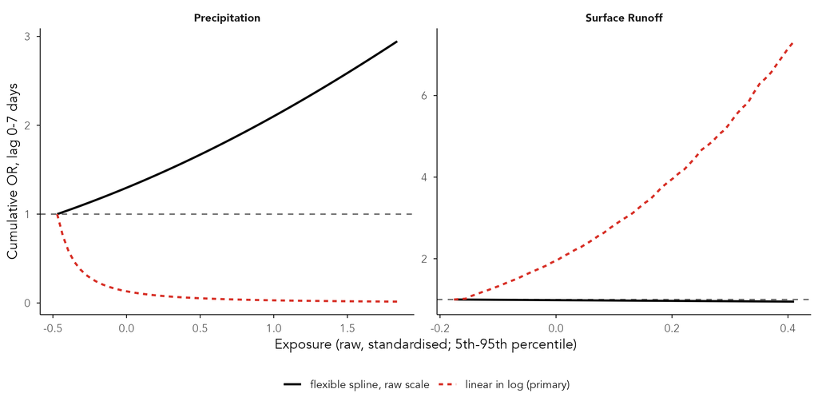

```r
shape_pair <- function(v) {
  cols <- paste0(v, "_Lag", LAGS)
  Xr <- as.matrix(NOLOG[, ..cols]); Xl <- as.matrix(LOG[, ..cols])
  qr <- quantile(Xr, c(.05, .95), na.rm = TRUE)
  at_r <- seq(qr[1], qr[2], length.out = 60)
  # the same cell-days expressed on each scale, so the two curves share an x axis
  ecdf_r <- ecdf(as.vector(Xr)); ql <- quantile(as.vector(Xl), ecdf_r(at_r), na.rm = TRUE)

  o_r <- assemble_cc_dlnm(NOLOG, max_lag = 28,
                          argvar_by_var = setNames(list(list(fun = "ns", df = 3)), v))
  f_r <- fit_cc_inla_dlnm(o_r)
  o_l <- assemble_cc_dlnm(LOG, max_lag = 28); f_l <- fit_cc_inla_dlnm(o_l)

  win <- 0:7
  cr <- vapply(at_r, function(a)
    met_lag_effect(f_r, o_r, v, win, step = a - qr[1])[["OR"]], numeric(1))
  cl <- vapply(ql, function(a)
    met_lag_effect(f_l, o_l, v, win, step = a - ql[1])[["OR"]], numeric(1))
  rbind(data.table(x = at_r, OR = cr, model = "flexible spline, raw scale"),
        data.table(x = at_r, OR = cl, model = "linear in log (primary)"))[
          , variable := unname(INLA_LABELS[v])][]
}
sh <- rbindlist(lapply(SKEW, shape_pair))

p <- ggplot(sh, aes(x, OR, colour = model, linetype = model)) +
  geom_hline(yintercept = 1, linetype = "dashed", colour = "grey40") +
  geom_line(linewidth = 0.8) +
  facet_wrap(~ variable, scales = "free") +
  scale_colour_manual(values = c("flexible spline, raw scale" = "black",
                                 "linear in log (primary)" = "#d73027")) +
  labs(x = "Exposure (raw, standardised; 5th-95th percentile)",
       y = "Cumulative OR, lag 0-7 days") +
  theme_minimal(base_family = "Avenir") +
  theme(panel.grid = element_blank(),
        axis.line = element_line(colour = "black", linewidth = 0.3),
        axis.ticks = element_line(colour = "black", linewidth = 0.3),
        strip.text = element_text(family = "Avenir Heavy"),
        legend.position = "bottom", legend.title = element_blank())
ggsave_spark(file.path(figures_sensitivity_folder, "figureS_log_shape_check.png"),
             p, width = 9, height = 4.5)
saveRDS(sh, paste0(objects_folder, "si_log_shape.RDS"))
p
```

# 5. Model fit: does the log beat a free shape on the raw scale?

The cleanest summary, and it does not depend on reading a curve by eye. If the log were merely imposing a convenient shape, a flexible spline free to choose any shape on the raw scale should fit at least as well.

| exposure-response | parameters | WAIC |
| --- | --- | --- |
| linear in log (primary) | 12 | **905.2** |
| linear in raw | 12 | 952.0 |
| spline (2 df) in raw | 16 | 948.4 |
| spline (3 df) in raw | 20 | 921.3 |

Linear-in-log fits better than a 3-df spline on the raw scale while using eight fewer parameters, and cross-validation on held-out matched sets agrees (paired z = -2.44 against the raw scale). The log is capturing real curvature parsimoniously rather than imposing it.